# Entrega 2: Genome-wide Association Studies

Big Data en Biociències

Francesc Aguirre, 1398024

Gener de 2021

# 1. Objectiu

Detectar nous SNPs associats a l’index de massa corporal (bmi), utilitzant les dades *coronary*.

# 2. Metodologia, anàlisi de dades i resultats

## 2.1 Obtenció de les dades i paquets

### 2.1.1 Paquets estadístics d’R

```r
library(snpStats)
library(magrittr)
library(qqman)

library(rvest)
library(stringr)
```

S’utilitzarà el paquet estadístic **snpStats** per facilitar l’anàlisi genètica GWAS, i el paquet **magrittr** per la creació de pipelines. El paquet **qqman** és molt útil per la creació de manhattan plots. Els paquets **rvest** i **stringr** s’han fet servir per web scrapping.

Qualsevol funció o codi R que no surti en aquest document es pot trobar a [github](https://github.com/cesc1/GWAS-example) (secció ANNEX).

### 2.1.2 Taula de dades

```r
setwd("..")
root_path <- getwd()

dataG <- read.plink(paste0(root_path, "/data/coronary"))
dataS <- read.table(paste0(root_path, "/data/coronary.txt"),
                    header = T, row.names = "id") # id s'ha fixat com a nom de fila
source(paste0(root_path, "/code/GWAS.R"))
```

S’han utilitzat dades d’un estudi epidemiològic sobre el bmi, on s’inclou la informació genètica de 425 individus en format plink, a més del gènere, edat, estat de fumador i el bmi.

## 2.2 Anàlisi descriptiva no genètica

En aquesta primera anàlisi descriptiva de les variables no genètiques, es busca una visualització ràpida de la distribució de les variables. També s’intenta detectar possibles errors de mostreig que puguin crear biaix en el futur anàlisi.

Taula 1: Estadistics univariants no genètics

| Variable | Levels/Method | n | Percent/quartils |
| --- | --- | --- | --- |
| gender | Females | 220 | 51.8 |
|  | Males | 205 | 48.2 |
| smoke | Current | 187 | 44.1 |
|  | Ex | 85 | 20.0 |
|  | Never | 152 | 35.8 |
| age | mean | 425 | (35.7, 41.3, 47.2) |
| bmi | median | 406 | (23.4, 25.9, 28.8) |
| ev4 | mean | 425 | (51.0, 52.3, 54.0) |
| ev3 | mean | 419 | (0.0, 0.0, 0.0) |

La Taula 1 d’estadístics univariants ens mostra, el percentatge per cada nivell en variables categòriques, o els quartils en dades numèriques (mediana si es detecta asimetria, mitjana si no es detecta). El nombre de persones fumadores o exfumadores és major que el 60% de la mostra i la edat dels individus tendeix a ser 40 anys. Es detecta la presència de valors perduts, sobretot en bmi (que és la nostre variable dependent), amb 19 NAs.

## 2.3 Control de qualitat

### 2.3.1 ID i sexe match

- S’ha comprobat que els identificadors dels dos fitxers de dades coincideixen, i estàn en el mateix ordre.

```r
dataS <- id_match(data = dataS, id = dataG$fam$member)
```

```
## Ordenant IDs...
```

Si tornem a executar la funció, podem comprobar que els identificadors dels dos fitxer coincideixen.

```r
dataS <- id_match(dataS, dataG$fam$member)
```

```
## Els IDs coincideixen!
```

- També s’ha comprobat que el sexe de cada individu en els dos fitxers coincideixen

```r
dataS$gender <- dataS$gender %>%
  factor(levels = c("Males", "Females")) %>%
  as.numeric()
all(dataS$gender == dataG$fam$sex)
```

```
## [1] TRUE
```

No es detecta cap problema.

### 2.3.2 Genotip

S’eliminaran de l’anàlisi els SNPs que continguin:

- Un nombre de valors perduts (individus) superior al 10%.
- Un test de Hardy-Weinberg (HWE) significatiu (0.01). Es fa per comprobar que les freqüències dels al·lels individuals coincideixin amb les poblacionals.
- Una freqüència d’al·lels minoritaris (MAF) inferior al 0.5%.

```r
dataG$genotypes <- dataG$genotypes %>%
  remove_indNA(minCallr = 0.90) %>%
  remove_HWE(signif = 0.01) %>%
  remove_MAF(minFreq = 0.005)
```

```
## - remove_indNA(): S'han eliminat 2289 individus
## - remove_HWE(): S'han eliminat 14037 individus, dels quals:
##   - 3458 tenien un p-valor < 0.010
##   - 10579 tenien un test NA
## - remove_MAF(): S'han eliminat 14003 individus, dels quals:
##   - 14003 tenien un MAF < 0.005
##   - 0 tenien un MAF NA
```

S’ha eliminat 30329 SNPs que no complien les condicions de qualitat, que són un 5.2% de dels SNPs inicials.

## 2.4 Selecció de variables no genètiques

### 2.4.1 Variables d’ajust

Les variables d’ajust ja es donen a l’enunciat, que són les variables **ev3** i **ev4**.

### 2.4.2 Components Principals

Tot i que les variables **ev3** i **ev4** ja representen l’ajust per estratificació de la població, s’il·lustra el procés d’obtenció de les components per poder-les ajustar més endavant.

```r
xxmat <- xxt(dataG$genotypes, correct.for.missing = FALSE)
```

```r
pca <- eigen(xxmat, symmetric = TRUE)
pcs <- pca$vectors[, 1:3]
```

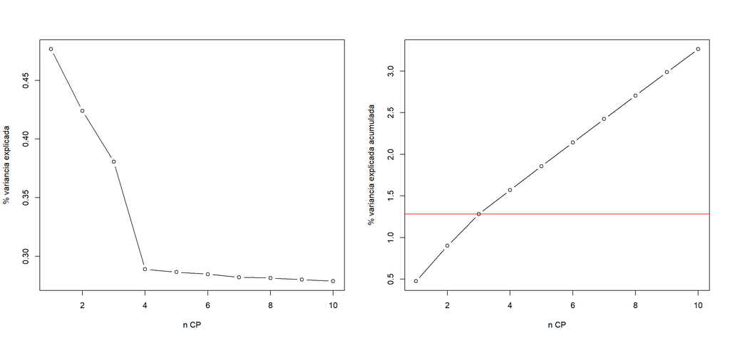

Grafic 1

Agafar 3 components principals sembla una bona opció en aquest cas, tot i que la variabilitat només arriba a 1.3%. S’hauria de comprobar si és suficient per explicar l’estratificació en la població del genotip.

## 2.5 Models d’associació genètica

Per cada SNP, s’ha creat un model lineal additiu.

Amb anterioritat ens han informat que les variables a ajustar són **ev3** i **ev4**. Com que ev4 només té 5 nivells, s’aplicarà la funció strata del paquet survival sobre aquesta.

```r
res <- snp.rhs.tests(bmi ~ ev3 + strata(ev4), family = "Gaussian",
                         data = dataS, snp.data = dataG$genotypes)

row <- rownames(dataG$map) %in% names(res)
taula <- data.frame(CHR = dataG$map$chromosome[row],
                    BP = dataG$map$position[row],
                    P = p.value(res),
                    SNP = names(res))

higher_snps <- taula[taula$P < 1e-05, ]
higher_snps <- higher_snps[order(higher_snps$P),]
```

Taula 2: SNPs més significatius

| Gene | CHR | BP | P | SNP |
| --- | --- | --- | --- | --- |
| HTATSF1 | 23 | 135416412 | 4.65e-08 | rs3027845 |
| CDKN2B | 9 | 21996607 | 8.23e-08 | rs3217980 |
| LMO7 | 13 | 75192888 | 6.46e-07 | rs9565191 |
| FGF1 | 5 | 141985761 | 9.65e-07 | rs10069453 |
|  | 12 | 76070972 | 1.25e-06 | rs7298190 |
| AUTS2 | 7 | 69681662 | 1.30e-06 | rs12530865 |
|  | 12 | 76078654 | 1.40e-06 | rs12816398 |
| LOC105376187 | 9 | 103635145 | 3.15e-06 | rs1337687 |
| CELF2 | 10 | 10649223 | 4.61e-06 | rs17148253 |
| CNTNAP4 | 16 | 74898406 | 5.82e-06 | rs9939043 |
|  | 7 | 25430129 | 6.59e-06 | rs17151612 |
| CNTNAP4 | 16 | 74899007 | 7.26e-06 | rs1428758 |

## 2.6 Manhattan plots

Els manhattan plots són uns gràfics molt útils, per visualitzar els SNPs més significatius, i detectar regions significatives d’associació. En l’eix d’ordenades tenim el negatiu del logaritme en base 10 del p-valor no corregit, calculat a la secció 2.5.

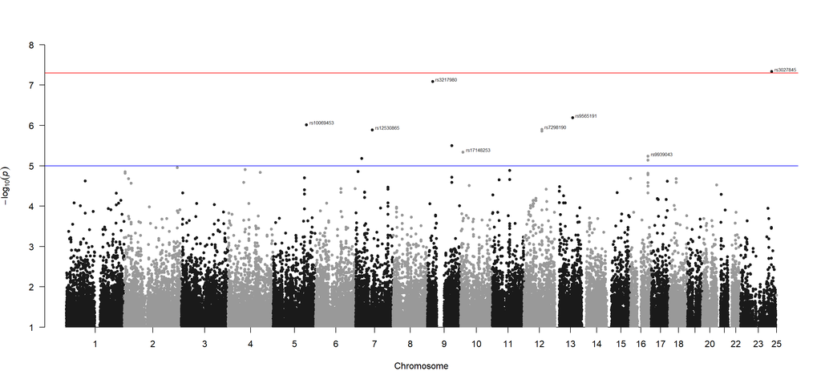

Grafic 2

```r
par(mfrow = c(1, 1))
taula_no_na <- taula %>%
  extract(complete.cases(taula),)

taula_no_na %>%
  extract(taula_no_na$P < 0.1,) %>%
  manhattan(ylim = c(1, 8), annotatePval = 1e-5)
```

L’SNP rs3027845 està per sobre de la línia vermella de significació, i el rs3217980 s’hi acosta molt, que també es podria arribar a conciderar significatiu. Com s’ha comentat en la secció 2.5, tenim 10 més SNPs que mereixen atenció, per sobre de 1e-5.

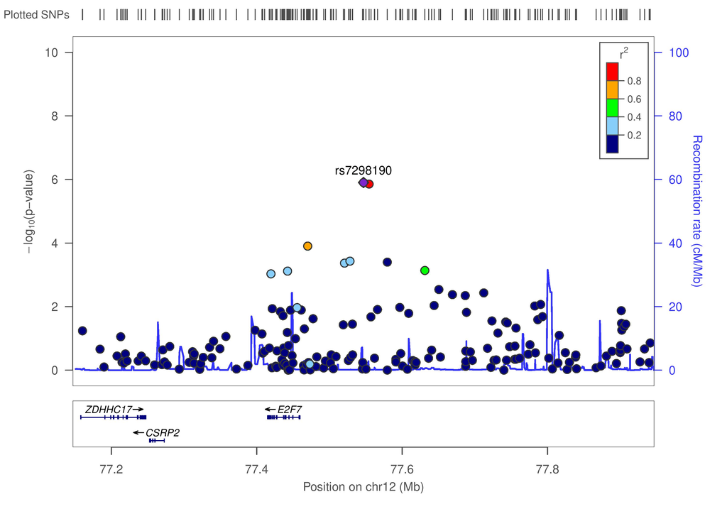

Grafic 3: Manhattan plot centrat en el SNP rs7298190

```r
taula_no_na %>%
  write.table(paste0(root_path, "/data/taulaP.txt"), quote = FALSE, row.names = FALSE)
```

En el Gràfic 3, ara podem veure amb més claretat els dos SNPs, que són molt propers i altament correlacionats. No s’observa cap més SNP significatiu per sota d’ells.

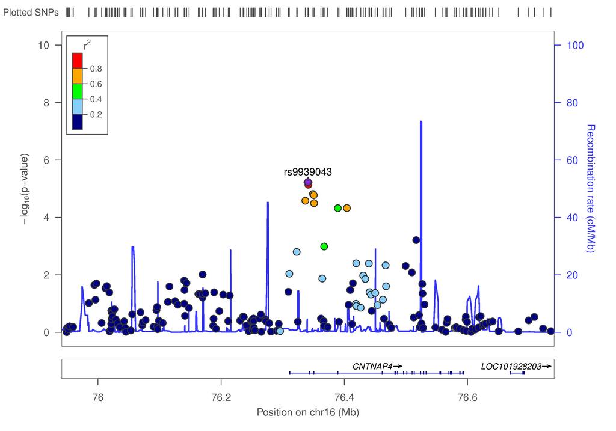

Grafic 4: Manhattan plot centrat en el SNP rs9939043

# 3. Conclusions

Els SNPs rs3027845 i rs3217980 s’han conciderat significatius, afectant a l’index de massa corporal directament. Els SNPs rs9565191, rs10069453, rs7298190, rs12530865, rs12816398, rs1337687, rs17148253, rs9939043, rs17151612 i rs1428758 s’han marcat com a possibles significatius. Es recomana tenir-los en compte en possibles estudis.

En concret, el snp rs9939043 està en una regió on s’han trobat més de 6 snps molt propers arribar a conciderar possibles significatius. En aquesta regió està el gen CNTNAP4, i es podria estudiar més endavant en estudis de xarxes de gens, per si té alguna relació amb l’índex de massa corporal.

# ANNEX

El codi d’aquesta entrega es pot trobar a github: cesc1/GWAS-example.